# Predict Bike Sharing Demand with AutoGluon

#### Download the Kaggle dataset using the kaggle python library

#### Install and import packages

```python
import warnings
warnings.filterwarnings('ignore')
```

### Setup Kaggle API Key

```python
import os
import json

# Replace with your actual Kaggle credentials
kaggle_username = "kamar1"
kaggle_key = "1499d85d10963c4a69ea8387c3d6e816"

# Define path in user's home directory
kaggle_dir = os.path.expanduser("~/.kaggle")
os.makedirs(kaggle_dir, exist_ok=True)

# Save kaggle.json with credentials
with open(os.path.join(kaggle_dir, "kaggle.json"), "w") as f:
    json.dump({"username": kaggle_username, "key": kaggle_key}, f)

# Set appropriate permissions
os.chmod(os.path.join(kaggle_dir, "kaggle.json"), 0o600)
```

### Download and explore dataset

```python
# Download the dataset, it will be in a .zip file so you'll need to unzip it as well.
!kaggle competitions download -c bike-sharing-demand

# If you already downloaded it you can use the -o command to overwrite the file
!unzip -o bike-sharing-demand.zip
```

```
bike-sharing-demand.zip: Skipping, found more recently modified local copy (use --force to force download)
Archive:  bike-sharing-demand.zip
  inflating: sampleSubmission.csv
  inflating: test.csv
  inflating: train.csv
```

```python
import pandas as pd
!pip install autogluon

from autogluon.tabular import TabularPredictor
```

```python
# Create the train dataset in pandas by reading the csv
# Set the parsing of the datetime column so you can use some of the `dt` features in pandas later
train = pd.read_csv('train.csv', parse_dates=['datetime'])
train.head()
```

|  | datetime | season | holiday | workingday | weather | temp | atemp | humidity | windspeed | casual | registered | count |
| --- | --- | --- | --- | --- | --- | --- | --- | --- | --- | --- | --- | --- |
| 0 | 2011-01-01 00:00:00 | 1 | 0 | 0 | 1 | 9.84 | 14.395 | 81 | 0.0 | 3 | 13 | 16 |
| 1 | 2011-01-01 01:00:00 | 1 | 0 | 0 | 1 | 9.02 | 13.635 | 80 | 0.0 | 8 | 32 | 40 |
| 2 | 2011-01-01 02:00:00 | 1 | 0 | 0 | 1 | 9.02 | 13.635 | 80 | 0.0 | 5 | 27 | 32 |
| 3 | 2011-01-01 03:00:00 | 1 | 0 | 0 | 1 | 9.84 | 14.395 | 75 | 0.0 | 3 | 10 | 13 |
| 4 | 2011-01-01 04:00:00 | 1 | 0 | 0 | 1 | 9.84 | 14.395 | 75 | 0.0 | 0 | 1 | 1 |

```python
# Simple output of the train dataset to view some of the min/max/varition of the dataset features.
train.describe()
```

|  | datetime | season | holiday | workingday | weather | temp | atemp | humidity | windspeed | casual | registered | count |
| --- | --- | --- | --- | --- | --- | --- | --- | --- | --- | --- | --- | --- |
| count | 10886 | 10886.000000 | 10886.000000 | 10886.000000 | 10886.000000 | 10886.00000 | 10886.000000 | 10886.000000 | 10886.000000 | 10886.000000 | 10886.000000 | 10886.000000 |
| mean | 2011-12-27 05:56:22.399411968 | 2.506614 | 0.028569 | 0.680875 | 1.418427 | 20.23086 | 23.655084 | 61.886460 | 12.799395 | 36.021955 | 155.552177 | 191.574132 |
| min | 2011-01-01 00:00:00 | 1.000000 | 0.000000 | 0.000000 | 1.000000 | 0.82000 | 0.760000 | 0.000000 | 0.000000 | 0.000000 | 0.000000 | 1.000000 |
| 25% | 2011-07-02 07:15:00 | 2.000000 | 0.000000 | 0.000000 | 1.000000 | 13.94000 | 16.665000 | 47.000000 | 7.001500 | 4.000000 | 36.000000 | 42.000000 |
| 50% | 2012-01-01 20:30:00 | 3.000000 | 0.000000 | 1.000000 | 1.000000 | 20.50000 | 24.240000 | 62.000000 | 12.998000 | 17.000000 | 118.000000 | 145.000000 |
| 75% | 2012-07-01 12:45:00 | 4.000000 | 0.000000 | 1.000000 | 2.000000 | 26.24000 | 31.060000 | 77.000000 | 16.997900 | 49.000000 | 222.000000 | 284.000000 |
| max | 2012-12-19 23:00:00 | 4.000000 | 1.000000 | 1.000000 | 4.000000 | 41.00000 | 45.455000 | 100.000000 | 56.996900 | 367.000000 | 886.000000 | 977.000000 |
| std | NaN | 1.116174 | 0.166599 | 0.466159 | 0.633839 | 7.79159 | 8.474601 | 19.245033 | 8.164537 | 49.960477 | 151.039033 | 181.144454 |

```python
# Create the test pandas dataframe in pandas by reading the csv, remember to parse the datetime!
test = pd.read_csv('test.csv', parse_dates=['datetime'])
test.head()
```

|  | datetime | season | holiday | workingday | weather | temp | atemp | humidity | windspeed |
| --- | --- | --- | --- | --- | --- | --- | --- | --- | --- |
| 0 | 2011-01-20 00:00:00 | 1 | 0 | 1 | 1 | 10.66 | 11.365 | 56 | 26.0027 |
| 1 | 2011-01-20 01:00:00 | 1 | 0 | 1 | 1 | 10.66 | 13.635 | 56 | 0.0000 |
| 2 | 2011-01-20 02:00:00 | 1 | 0 | 1 | 1 | 10.66 | 13.635 | 56 | 0.0000 |
| 3 | 2011-01-20 03:00:00 | 1 | 0 | 1 | 1 | 10.66 | 12.880 | 56 | 11.0014 |
| 4 | 2011-01-20 04:00:00 | 1 | 0 | 1 | 1 | 10.66 | 12.880 | 56 | 11.0014 |

```python
# Same thing as train and test dataset
submission = pd.read_csv("sampleSubmission.csv", parse_dates=["datetime"])
submission.head()
```

|  | datetime | count |
| --- | --- | --- |
| 0 | 2011-01-20 00:00:00 | 0 |
| 1 | 2011-01-20 01:00:00 | 0 |
| 2 | 2011-01-20 02:00:00 | 0 |
| 3 | 2011-01-20 03:00:00 | 0 |
| 4 | 2011-01-20 04:00:00 | 0 |

## Train a model using AutoGluon’s Tabular Prediction

- We are predicting `count`, so it is the label we are setting.
- Ignore `casual` and `registered` columns as they are also not present in the test dataset.
- Use the `root_mean_squared_error` as the metric to use for evaluation.
- Set a time limit of 10 minutes (600 seconds).
- Use the preset `best_quality` to focus on creating the best model.

```python
train.drop(columns=['casual', 'registered'], axis=1, inplace=True)
```

```python
predictor = TabularPredictor(label='count',
                            problem_type='regression',
                            eval_metric='root_mean_squared_error'
                            ).fit(train_data = train,
                                 time_limit = 600,
                                 presets= 'best_quality')
```

[output not shown]

[output cut: 31 more lines]

[output not shown]

```
(_ray_fit pid=177674) [1000]	valid_set's rmse: 129.692
(_ray_fit pid=177678) [8000]	valid_set's rmse: 125.498 [repeated 32x across cluster] (Ray deduplicates logs by default. Set RAY_DEDUP_LOGS=0 to disable log deduplication, or see https://docs.ray.io/en/master/ray-observability/user-guides/configure-logging.html#log-deduplication for more options.)
```

[output not shown]

```
(_ray_fit pid=184590) [1000]	valid_set's rmse: 69.4714 [repeated 12x across cluster]
```

[output not shown]

[output cut: 207 more lines]

```
	-55.8483	 = Validation score   (-root_mean_squared_error)
	3.94s	 = Training   runtime
	0.03s	 = Validation runtime
Fitting model: NeuralNetTorch_r79_BAG_L2 ... Training model for up to 22.92s of the 22.80s of remaining time.
	Fitting 8 child models (S1F1 - S1F8) | Fitting with ParallelLocalFoldFittingStrategy (8 workers, per: cpus=6, gpus=0, memory=0.01%)
	-53.1992	 = Validation score   (-root_mean_squared_error)
	19.49s	 = Training   runtime
	0.11s	 = Validation runtime
Fitting model: WeightedEnsemble_L3 ... Training model for up to 360.00s of the 1.88s of remaining time.
	Ensemble Weights: {'NeuralNetFastAI_BAG_L2': 0.4, 'RandomForestMSE_BAG_L2': 0.2, 'NeuralNetTorch_BAG_L2': 0.15, 'NeuralNetTorch_r79_BAG_L2': 0.15, 'ExtraTreesMSE_BAG_L2': 0.1}
	-50.1787	 = Validation score   (-root_mean_squared_error)
	0.03s	 = Training   runtime
	0.0s	 = Validation runtime
AutoGluon training complete, total runtime = 442.18s ... Best model: WeightedEnsemble_L3 | Estimated inference throughput: 599.6 rows/s (1361 batch size)
TabularPredictor saved. To load, use: predictor = TabularPredictor.load("/home/cs/bike-prediction/AutogluonModels/ag-20250609_172601")
```

### Review AutoGluon's training run with ranking of models that did the best.

```python
predictor.fit_summary()
```

```
*** Summary of fit() ***
Estimated performance of each model:
                        model   score_val              eval_metric  pred_time_val    fit_time  pred_time_val_marginal  fit_time_marginal  stack_level  can_infer  fit_order
0         WeightedEnsemble_L3  -50.178749  root_mean_squared_error       3.528578  390.002385                0.000341           0.029902            3       True         27
1      NeuralNetFastAI_BAG_L2  -51.622291  root_mean_squared_error       2.576669  290.802032                0.147556          10.254183            2       True         21
2   NeuralNetTorch_r79_BAG_L2  -53.199232  root_mean_squared_error       2.542446  300.040629                0.113334          19.492779            2       True         26
3      RandomForestMSE_BAG_L2  -53.551924  root_mean_squared_error       2.803531  282.102403                0.374418           1.554553            2       True         18
4        ExtraTreesMSE_BAG_L2  -54.250442  root_mean_squared_error       2.790681  281.078305                0.361569           0.530455            2       True         20
5       NeuralNetTorch_BAG_L2  -54.827028  root_mean_squared_error       2.531359  358.140513                0.102247          77.592664            2       True         23
6        LightGBMLarge_BAG_L2  -54.925363  root_mean_squared_error       2.481523  284.273716                0.052410           3.725866            2       True         24
7             LightGBM_BAG_L2  -55.174250  root_mean_squared_error       2.463031  282.050697                0.033918           1.502847            2       True         17
8              XGBoost_BAG_L2  -55.402042  root_mean_squared_error       2.474708  281.783321                0.045595           1.235471            2       True         22
9             CatBoost_BAG_L2  -55.629803  root_mean_squared_error       2.458646  286.409131                0.029534           5.861281            2       True         19
10       CatBoost_r177_BAG_L2  -55.848336  root_mean_squared_error       2.457383  284.487656                0.028271           3.939806            2       True         25
11          LightGBMXT_BAG_L2  -60.063423  root_mean_squared_error       2.729732  285.455582                0.300620           4.907733            2       True         16
12      KNeighborsDist_BAG_L1  -84.125061  root_mean_squared_error       0.030228    0.021022                0.030228           0.021022            1       True          2
13        WeightedEnsemble_L2  -84.125061  root_mean_squared_error       0.030515    0.041544                0.000287           0.020522            2       True         15
14      KNeighborsUnif_BAG_L1 -101.546199  root_mean_squared_error       0.032834    0.022670                0.032834           0.022670            1       True          1
15     RandomForestMSE_BAG_L1 -116.548359  root_mean_squared_error       0.320674    0.586048                0.320674           0.586048            1       True          5
16       ExtraTreesMSE_BAG_L1 -124.600676  root_mean_squared_error       0.318367    0.562904                0.318367           0.562904            1       True          7
17       LightGBM_r131_BAG_L1 -129.862938  root_mean_squared_error       0.443073    6.981948                0.443073           6.981948            1       True         14
18       LightGBMLarge_BAG_L1 -130.035209  root_mean_squared_error       0.063980    3.339643                0.063980           3.339643            1       True         11
19            CatBoost_BAG_L1 -130.461205  root_mean_squared_error       0.038541   44.029736                0.038541          44.029736            1       True          6
20       CatBoost_r177_BAG_L1 -130.672167  root_mean_squared_error       0.031388   14.772634                0.031388          14.772634            1       True         12
21            LightGBM_BAG_L1 -131.054162  root_mean_squared_error       0.114427    2.397519                0.114427           2.397519            1       True          4
22          LightGBMXT_BAG_L1 -131.460909  root_mean_squared_error       0.693276    8.330473                0.693276           8.330473            1       True          3
23             XGBoost_BAG_L1 -131.893935  root_mean_squared_error       0.068710    1.015347                0.068710           1.015347            1       True          9
24     NeuralNetFastAI_BAG_L1 -136.063262  root_mean_squared_error       0.125951    9.426414                0.125951           9.426414            1       True          8
25      NeuralNetTorch_BAG_L1 -136.780689  root_mean_squared_error       0.068742  146.740866                0.068742         146.740866            1       True         10
26  NeuralNetTorch_r79_BAG_L1 -138.439208  root_mean_squared_error       0.078922   42.320625                0.078922          42.320625            1       True         13
Number of models trained: 27
Types of models trained:
{'StackerEnsembleModel_LGB', 'StackerEnsembleModel_XGBoost', 'StackerEnsembleModel_NNFastAiTabular', 'WeightedEnsembleModel', 'StackerEnsembleModel_CatBoost', 'StackerEnsembleModel_XT', 'StackerEnsembleModel_RF', 'StackerEnsembleModel_TabularNeuralNetTorch', 'StackerEnsembleModel_KNN'}
Bagging used: True  (with 8 folds)
Multi-layer stack-ensembling used: True  (with 3 levels)
Feature Metadata (Processed):
(raw dtype, special dtypes):
('float', [])                : 3 | ['temp', 'atemp', 'windspeed']
('int', [])                  : 3 | ['season', 'weather', 'humidity']
('int', ['bool'])            : 2 | ['holiday', 'workingday']
('int', ['datetime_as_int']) : 5 | ['datetime', 'datetime.year', 'datetime.month', 'datetime.day', 'datetime.dayofweek']
*** End of fit() summary ***
```

[output not shown]

[output cut: 391 more lines]

```
 12            1       True          2
 13            2       True         15
 14            1       True          1
 15            1       True          5
 16            1       True          7
 17            1       True         14
 18            1       True         11
 19            1       True          6
 20            1       True         12
 21            1       True          4
 22            1       True          3
 23            1       True          9
 24            1       True          8
 25            1       True         10
 26            1       True         13  }
```

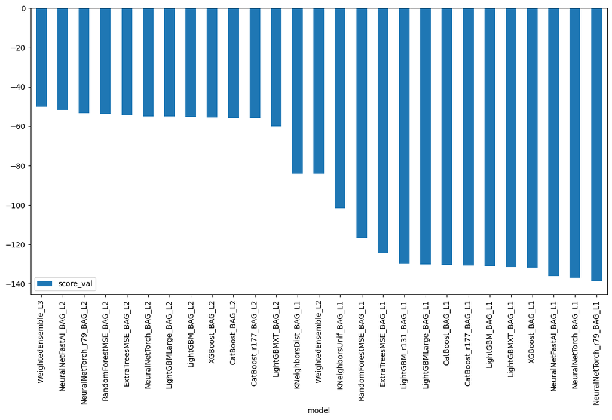

```python
import matplotlib.pyplot as plt
predictor.leaderboard(silent=True).plot(kind="bar", x="model", y="score_val", figsize=(14, 7))
plt.show()
```

### Create predictions from test dataset

```python
predictions = predictor.predict(test)
predictions.head()
```

```
0    26.896637
1    40.783520
2    45.495506
3    49.761093
4    51.858849
Name: count, dtype: float32
```

#### NOTE: Kaggle will reject the submission if we don't set everything to be > 0.

```python
# Describe the `predictions` series to see if there are any negative values
predictions.describe()
```

```
count    6493.000000
mean       99.650139
std        89.589111
min         3.035333
25%        19.464420
50%        63.934860
75%       170.554260
max       351.736511
Name: count, dtype: float64
```

```python
# How many negative values do we have?
print("Total Predictions: ", len(predictions))
print("Total Positive Predictions: ", (predictions > 0).sum())
print("Total Negative Predictions: ", (predictions < 0).sum())
```

```
Total Predictions:  6493
Total Positive Predictions:  6493
Total Negative Predictions:  0
```

```python
# Set them to zero
if (predictions < 0).any():
    predictions = predictions[predictions < 0] = 0
    print("All Negative values set to zero")
else:
    print("No Negative value in Predictions")
```

```
No Negative value in Predictions
```

### Set predictions to submission dataframe, save, and submit

```python
submission["count"] = predictions
submission.to_csv("submission.csv", index=False)
```

```python
!kaggle competitions submit -c bike-sharing-demand -f submission.csv -m "first raw submission"
```

```
Successfully submitted to Bike Sharing Demand
```

#### View submission via the command line or in the web browser under the competition's page - `My Submissions`

```python
!kaggle competitions submissions -c bike-sharing-demand | tail -n +1 | head -n 6
```

```
fileName        date                        description           status                     publicScore  privateScore
--------------  --------------------------  --------------------  -------------------------  -----------  ------------
submission.csv  2025-06-09 17:38:29.207000  first raw submission  SubmissionStatus.COMPLETE  1.81758      1.81758
```

## Exploratory Data Analysis and Creating additional features

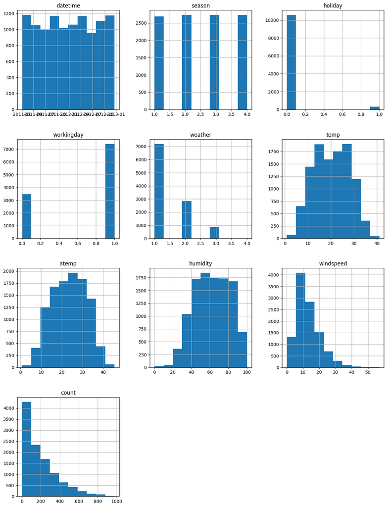

```python
# histogram of all features to show the distribution of each one relative to the data. This is part of the exploritory data analysis
import matplotlib.pyplot as plt
train.hist(figsize=(15,20))
plt.show()
```

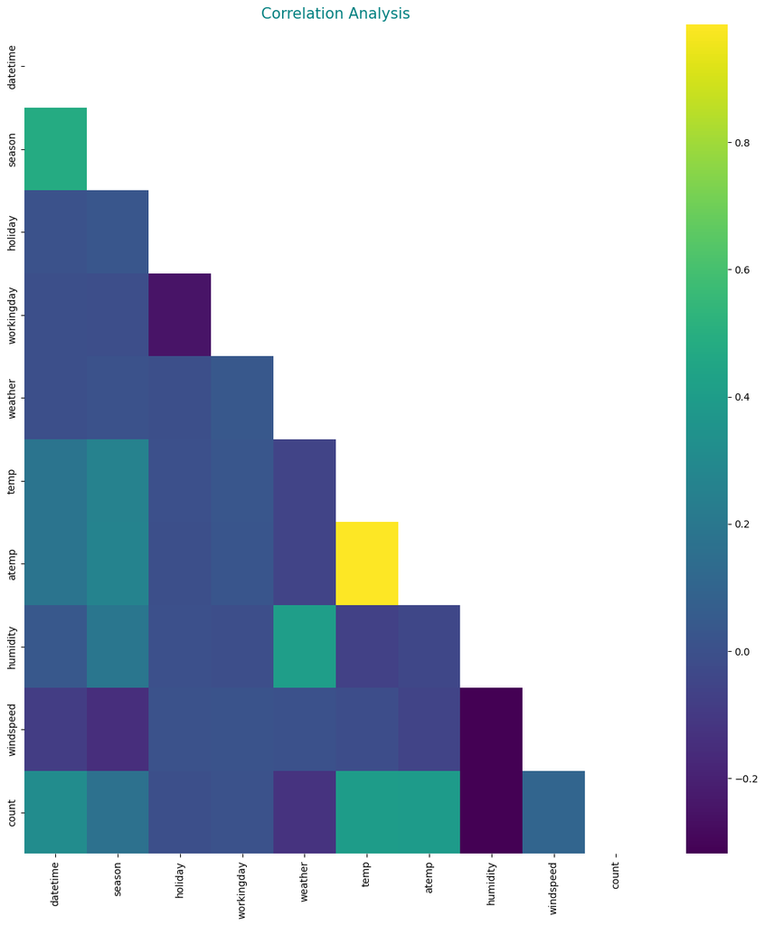

```python
import seaborn as sns
import numpy as np
plt.figure(figsize=(14,15))
corr= train.corr()
mask= np.triu(corr)
plt.title('Correlation Analysis',
         fontsize=15,
         color='teal')
sns.heatmap(corr,
           mask=mask,
           annot=True,
           lw=0,
           linecolor='white',
           cmap='viridis',
           fmt='0.2f')
plt.xticks(rotation=90, fontsize=10)
plt.yticks(fontsize=10)
plt.show()
```

```python
import datetime
train['datetime'].head()
```

```
0   2011-01-01 00:00:00
1   2011-01-01 01:00:00
2   2011-01-01 02:00:00
3   2011-01-01 03:00:00
4   2011-01-01 04:00:00
Name: datetime, dtype: datetime64[ns]
```

```python
# create a new training data feature
train['year'] = train['datetime'].dt.year
train['month'] = train['datetime'].dt.month
train['day'] = train['datetime'].dt.dayofweek
train['hour'] = train['datetime'].dt.hour
train.drop(columns='datetime', inplace=True)
```

```python
# create a new test feature
test['year'] = test['datetime'].dt.year
test['month'] = test['datetime'].dt.month
test['day'] = test['datetime'].dt.dayofweek
test['hour'] = test['datetime'].dt.hour
test.drop(columns='datetime', inplace=True)
```

## Make category types for these so models know they are not just numbers

- AutoGluon originally sees these as ints, but in reality they are int representations of a category.
- Setting the dtype to category will classify these as categories in AutoGluon.

```python
train["season"] = train["season"].astype('category')
train["weather"] = train["weather"].astype('category')

test["season"] = test["season"].astype('category')
test["weather"] = test["weather"].astype('category')
```

```python
# View are new feature
train.head()
```

|  | season | holiday | workingday | weather | temp | atemp | humidity | windspeed | count | year | month | day | hour |
| --- | --- | --- | --- | --- | --- | --- | --- | --- | --- | --- | --- | --- | --- |
| 0 | 1 | 0 | 0 | 1 | 9.84 | 14.395 | 81 | 0.0 | 16 | 2011 | 1 | 5 | 0 |
| 1 | 1 | 0 | 0 | 1 | 9.02 | 13.635 | 80 | 0.0 | 40 | 2011 | 1 | 5 | 1 |
| 2 | 1 | 0 | 0 | 1 | 9.02 | 13.635 | 80 | 0.0 | 32 | 2011 | 1 | 5 | 2 |
| 3 | 1 | 0 | 0 | 1 | 9.84 | 14.395 | 75 | 0.0 | 13 | 2011 | 1 | 5 | 3 |
| 4 | 1 | 0 | 0 | 1 | 9.84 | 14.395 | 75 | 0.0 | 1 | 2011 | 1 | 5 | 4 |

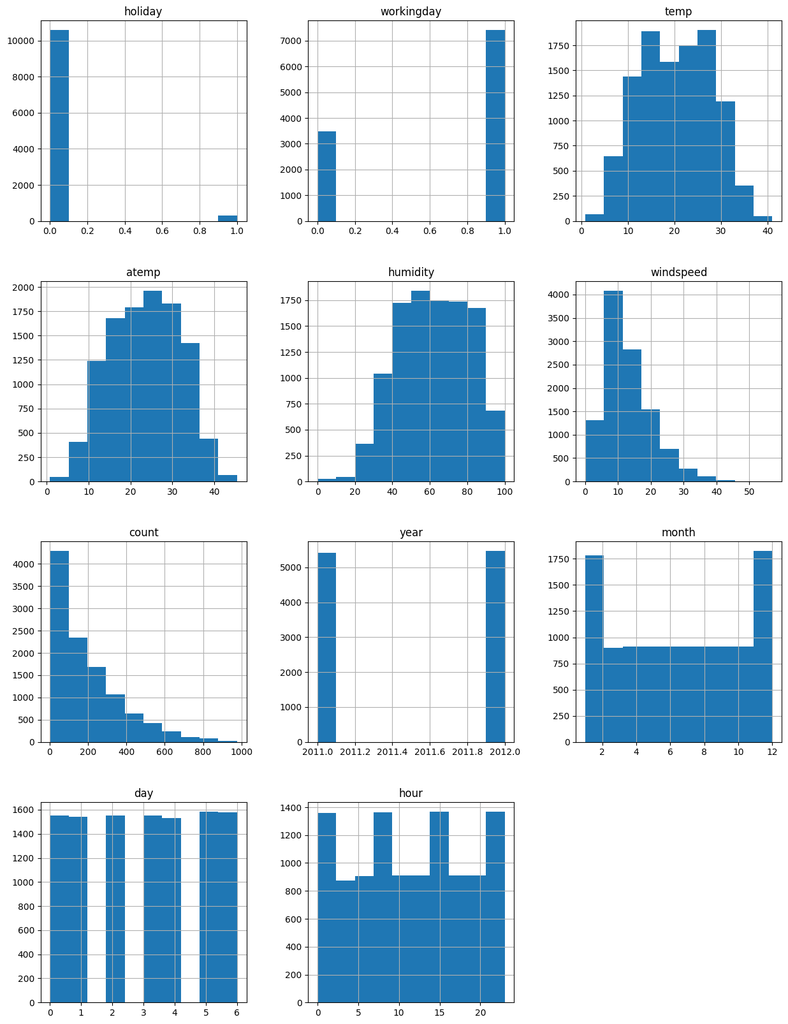

```python
# View histogram of all features again now with the hour feature
train.hist(figsize=(15,20))
plt.show()
```

## Rerun the model with the same settings as before, just with more features

```python
predictor_new_features = TabularPredictor(label='count',
                            problem_type='regression',
                            eval_metric='root_mean_squared_error'
                            ).fit(train_data = train,
                                 time_limit = 600,
                                 presets= 'best_quality')
```

```
No path specified. Models will be saved in: "AutogluonModels/ag-20250609_173940"
Verbosity: 2 (Standard Logging)
=================== System Info ===================
AutoGluon Version:  1.3.1
Python Version:     3.11.7
Operating System:   Linux
Platform Machine:   x86_64
Platform Version:   #63~22.04.1-Ubuntu SMP PREEMPT_DYNAMIC Tue Apr 22 19:00:15 UTC 2
CPU Count:          48
Memory Avail:       105.19 GB / 125.63 GB (83.7%)
Disk Space Avail:   644.59 GB / 870.05 GB (74.1%)
===================================================
Presets specified: ['best_quality']
Setting dynamic_stacking from 'auto' to True. Reason: Enable dynamic_stacking when use_bag_holdout is disabled. (use_bag_holdout=False)
Stack configuration (auto_stack=True): num_stack_levels=1, num_bag_folds=8, num_bag_sets=1
DyStack is enabled (dynamic_stacking=True). AutoGluon will try to determine whether the input data is affected by stacked overfitting and enable or disable stacking as a consequence.
	This is used to identify the optimal `num_stack_levels` value. Copies of AutoGluon will be fit on subsets of the data. Then holdout validation data is used to detect stacked overfitting.
	Running DyStack for up to 150s of the 600s of remaining time (25%).
		Context path: "/home/cs/bike-prediction/AutogluonModels/ag-20250609_173940/ds_sub_fit/sub_fit_ho"
Leaderboard on holdout data (DyStack):
                     model  score_holdout   score_val              eval_metric  pred_time_test  pred_time_val    fit_time  pred_time_test_marginal  pred_time_val_marginal  fit_time_marginal  stack_level  can_infer  fit_order
0   NeuralNetFastAI_BAG_L2     -33.056448  -35.176951  root_mean_squared_error        5.071011       2.308910  100.333601                 0.121248                0.105393           9.140834            2       True         17
1      WeightedEnsemble_L3     -33.072198  -34.622883  root_mean_squared_error        5.503254       3.106818  124.826092                 0.001955                0.000322           0.022815            3       True         21
2      WeightedEnsemble_L2     -33.493348  -34.710972  root_mean_squared_error        1.936161       1.779962   75.323974                 0.001437                0.000269           0.014390            2       True         11
3          LightGBM_BAG_L2     -33.515764  -35.438047  root_mean_squared_error        4.975540       2.224738   92.220070                 0.025777                0.021221           1.027304            2       True         13
4     ExtraTreesMSE_BAG_L2     -33.553811  -35.082222  root_mean_squared_error        5.114777       2.531006   91.696558                 0.165014                0.327489           0.503791            2       True         16
5     LightGBMLarge_BAG_L2     -33.662851  -36.205274  root_mean_squared_error        5.027276       2.247312   93.177114                 0.077512                0.043795           1.984347            2       True         20
6          CatBoost_BAG_L2     -33.665210  -35.176179  root_mean_squared_error        4.971454       2.230206   95.033597                 0.021691                0.026689           3.840830            2       True         15
7           XGBoost_BAG_L2     -33.727631  -35.730157  root_mean_squared_error        5.079278       2.260922   92.085891                 0.129514                0.057405           0.893125            2       True         18
8        LightGBMXT_BAG_L2     -33.747505  -35.803566  root_mean_squared_error        4.999883       2.240306   92.398659                 0.050120                0.036788           1.205892            2       True         12
9          CatBoost_BAG_L1     -33.788629  -35.944063  root_mean_squared_error        0.417681       0.054531   61.289212                 0.417681                0.054531          61.289212            1       True          6
10  RandomForestMSE_BAG_L2     -33.956594  -35.593195  root_mean_squared_error        5.102134       2.553758   92.388485                 0.152370                0.350241           1.195719            2       True         14
11   NeuralNetTorch_BAG_L2     -34.221946  -36.001082  root_mean_squared_error        5.040975       2.296684  110.122103                 0.091212                0.093167          18.929337            2       True         19
12         LightGBM_BAG_L1     -34.290222  -36.666362  root_mean_squared_error        0.124517       0.158100    3.148291                 0.124517                0.158100           3.148291            1       True          4
13          XGBoost_BAG_L1     -35.343851  -37.804883  root_mean_squared_error        0.188887       0.098111    1.276181                 0.188887                0.098111           1.276181            1       True          9
14       LightGBMXT_BAG_L1     -35.601417  -36.938407  root_mean_squared_error        0.957094       0.909507    9.833450                 0.957094                0.909507           9.833450            1       True          3
15    ExtraTreesMSE_BAG_L1     -38.181076  -39.852555  root_mean_squared_error        0.126739       0.332862    0.508347                 0.126739                0.332862           0.508347            1       True          7
16  RandomForestMSE_BAG_L1     -40.274031  -40.568964  root_mean_squared_error        0.308692       0.324692    0.530283                 0.308692                0.324692           0.530283            1       True          5
17  NeuralNetFastAI_BAG_L1     -45.270306  -47.539401  root_mean_squared_error        2.735514       0.119518    9.743333                 2.735514                0.119518           9.743333            1       True          8
18   NeuralNetTorch_BAG_L1     -88.543137  -90.656794  root_mean_squared_error        0.050576       0.051621    4.842475                 0.050576                0.051621           4.842475            1       True         10
```

[output cut: 188 more lines]

```
	-33.5979	 = Validation score   (-root_mean_squared_error)
	23.32s	 = Training   runtime
	0.34s	 = Validation runtime
Fitting model: CatBoost_r9_BAG_L2 ... Training model for up to 10.97s of the 10.95s of remaining time.
	Fitting 8 child models (S1F1 - S1F8) | Fitting with ParallelLocalFoldFittingStrategy (8 workers, per: cpus=6, gpus=0, memory=0.39%)
	-33.5749	 = Validation score   (-root_mean_squared_error)
	7.7s	 = Training   runtime
	0.05s	 = Validation runtime
Fitting model: WeightedEnsemble_L3 ... Training model for up to 360.00s of the 1.81s of remaining time.
	Ensemble Weights: {'CatBoost_r177_BAG_L2': 0.273, 'ExtraTreesMSE_BAG_L2': 0.182, 'NeuralNetFastAI_BAG_L2': 0.136, 'NeuralNetTorch_BAG_L1': 0.091, 'CatBoost_r177_BAG_L1': 0.091, 'NeuralNetTorch_r79_BAG_L2': 0.091, 'XGBoost_BAG_L2': 0.045, 'LightGBM_r131_BAG_L2': 0.045, 'NeuralNetFastAI_r191_BAG_L2':…
	-33.1167	 = Validation score   (-root_mean_squared_error)
	0.03s	 = Training   runtime
	0.0s	 = Validation runtime
AutoGluon training complete, total runtime = 439.01s ... Best model: WeightedEnsemble_L3 | Estimated inference throughput: 405.4 rows/s (1361 batch size)
TabularPredictor saved. To load, use: predictor = TabularPredictor.load("/home/cs/bike-prediction/AutogluonModels/ag-20250609_173940")
```

```python
predictor_new_features.fit_summary()
```

```
*** Summary of fit() ***
Estimated performance of each model:
                          model   score_val              eval_metric  pred_time_val    fit_time  pred_time_val_marginal  fit_time_marginal  stack_level  can_infer  fit_order
0           WeightedEnsemble_L3  -33.116723  root_mean_squared_error       4.403172  367.731869                0.000306           0.031274            3       True         29
1           WeightedEnsemble_L2  -33.278607  root_mean_squared_error       2.110725  263.304526                0.000342           0.018950            2       True         14
2          CatBoost_r177_BAG_L2  -33.545039  root_mean_squared_error       3.276627  282.631197                0.026994           1.859648            2       True         24
3            CatBoost_r9_BAG_L2  -33.574881  root_mean_squared_error       3.295249  288.471399                0.045615           7.699849            2       True         28
4   NeuralNetFastAI_r191_BAG_L2  -33.597866  root_mean_squared_error       3.585824  304.087572                0.336190          23.316023            2       True         27
5          ExtraTreesMSE_BAG_L2  -33.634275  root_mean_squared_error       3.625750  281.267129                0.376117           0.495580            2       True         19
6               CatBoost_BAG_L2  -33.722190  root_mean_squared_error       3.277268  284.594135                0.027634           3.822585            2       True         18
7        NeuralNetFastAI_BAG_L2  -33.725048  root_mean_squared_error       3.394219  291.542949                0.144585          10.771400            2       True         20
8               LightGBM_BAG_L2  -33.808944  root_mean_squared_error       3.273094  281.871829                0.023461           1.100280            2       True         16
9          LightGBM_r131_BAG_L2  -33.833862  root_mean_squared_error       3.309124  282.972298                0.059490           2.200748            2       True         26
10               XGBoost_BAG_L2  -33.995774  root_mean_squared_error       3.313333  281.859914                0.063699           1.088365            2       True         21
11       RandomForestMSE_BAG_L2  -34.070070  root_mean_squared_error       3.652423  282.302528                0.402789           1.530979            2       True         17
12    NeuralNetTorch_r79_BAG_L2  -34.117340  root_mean_squared_error       3.395790  327.968831                0.146157          47.197282            2       True         25
13            LightGBMXT_BAG_L2  -34.251116  root_mean_squared_error       3.285076  282.077402                0.035442           1.305852            2       True         15
14         LightGBMLarge_BAG_L2  -34.482551  root_mean_squared_error       3.287127  283.302377                0.037493           2.530828            2       True         23
15        NeuralNetTorch_BAG_L2  -34.624218  root_mean_squared_error       3.364437  300.957422                0.114803          20.185873            2       True         22
16         CatBoost_r177_BAG_L1  -35.078833  root_mean_squared_error       0.035652   22.638445                0.035652          22.638445            1       True         12
17              CatBoost_BAG_L1  -35.178592  root_mean_squared_error       0.063839   67.939533                0.063839          67.939533            1       True          6
18         LightGBMLarge_BAG_L1  -35.254820  root_mean_squared_error       0.164824    5.785680                0.164824           5.785680            1       True         11
19              LightGBM_BAG_L1  -35.796869  root_mean_squared_error       0.184786    3.801219                0.184786           3.801219            1       True          4
20            LightGBMXT_BAG_L1  -36.459884  root_mean_squared_error       1.606930    9.704578                1.606930           9.704578            1       True          3
21               XGBoost_BAG_L1  -36.997414  root_mean_squared_error       0.125860    1.482154                0.125860           1.482154            1       True          9
22        NeuralNetTorch_BAG_L1  -38.330658  root_mean_squared_error       0.054351  153.416121                0.054351         153.416121            1       True         10
23         ExtraTreesMSE_BAG_L1  -39.033394  root_mean_squared_error       0.337838    0.503084                0.337838           0.503084            1       True          7
24       RandomForestMSE_BAG_L1  -39.587441  root_mean_squared_error       0.340911    0.555482                0.340911           0.555482            1       True          5
25       NeuralNetFastAI_BAG_L1  -46.490169  root_mean_squared_error       0.123328   10.295056                0.123328          10.295056            1       True          8
26    NeuralNetTorch_r79_BAG_L1  -83.127297  root_mean_squared_error       0.071415    4.604877                0.071415           4.604877            1       True         13
27        KNeighborsDist_BAG_L1 -112.157112  root_mean_squared_error       0.077142    0.028049                0.077142           0.028049            1       True          2
28        KNeighborsUnif_BAG_L1 -115.733231  root_mean_squared_error       0.062755    0.017271                0.062755           0.017271            1       True          1
Number of models trained: 29
Types of models trained:
{'StackerEnsembleModel_LGB', 'StackerEnsembleModel_XGBoost', 'StackerEnsembleModel_NNFastAiTabular', 'WeightedEnsembleModel', 'StackerEnsembleModel_CatBoost', 'StackerEnsembleModel_XT', 'StackerEnsembleModel_RF', 'StackerEnsembleModel_TabularNeuralNetTorch', 'StackerEnsembleModel_KNN'}
Bagging used: True  (with 8 folds)
Multi-layer stack-ensembling used: True  (with 3 levels)
Feature Metadata (Processed):
(raw dtype, special dtypes):
('category', [])  : 2 | ['season', 'weather']
('float', [])     : 3 | ['temp', 'atemp', 'windspeed']
('int', [])       : 4 | ['humidity', 'month', 'day', 'hour']
('int', ['bool']) : 3 | ['holiday', 'workingday', 'year']
*** End of fit() summary ***
```

[output not shown]

[output cut: 423 more lines]

```
 14            2       True         23
 15            2       True         22
 16            1       True         12
 17            1       True          6
 18            1       True         11
 19            1       True          4
 20            1       True          3
 21            1       True          9
 22            1       True         10
 23            1       True          7
 24            1       True          5
 25            1       True          8
 26            1       True         13
 27            1       True          2
 28            1       True          1  }
```

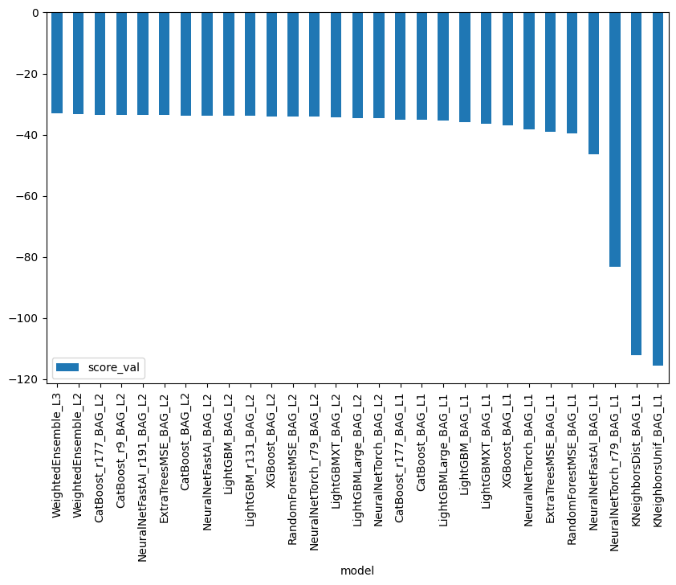

```python
predictor_new_features.leaderboard(silent=True).plot(kind="bar", x="model", y="score_val", figsize=(10, 6))
plt.show()
```

```python
new_predictions = predictor_new_features.predict(test)
new_predictions.head()
```

```
0    13.016307
1     6.034476
2     4.153350
3     3.331968
4     3.216386
Name: count, dtype: float32
```

```python
new_predictions.describe()
```

```
count    6493.000000
mean      189.827927
std       174.371719
min        -1.842135
25%        44.167271
50%       147.120605
75%       282.084015
max       909.021362
Name: count, dtype: float64
```

```python
# Set negative values to zero
new_predictions[new_predictions < 0] = 0

# Count the total positive and negative predictions
total_predictions = len(new_predictions)
total_positive_predictions = (new_predictions > 0).sum()
total_negative_predictions = (new_predictions < 0).sum()  # Because we set negatives to zero

print("Total Predictions:", total_predictions)
print("Total Positive Predictions:", total_positive_predictions)
print("Total Negative Predictions:", total_negative_predictions)
```

```
Total Predictions: 6493
Total Positive Predictions: 6491
Total Negative Predictions: 0
```

```python
submission_new_features = pd.read_csv("sampleSubmission.csv", parse_dates = ['datetime'])
```

```python
# Same submitting predictions
submission_new_features["count"] = new_predictions
submission_new_features.to_csv("submission_new_features.csv", index=False)
```

```python
!kaggle competitions submit -c bike-sharing-demand -f submission_new_features.csv -m "new features"
```

```
Successfully submitted to Bike Sharing Demand
```

```python
!kaggle competitions submissions -c bike-sharing-demand | tail -n +1 | head -n 6
```

```
fileName                     date                        description           status                     publicScore  privateScore
---------------------------  --------------------------  --------------------  -------------------------  -----------  ------------
submission_new_features.csv  2025-06-09 17:51:13.577000  new features          SubmissionStatus.COMPLETE  0.44664      0.44664
submission.csv               2025-06-09 17:38:29.207000  first raw submission  SubmissionStatus.COMPLETE  1.81758      1.81758
```